# Visualising similarity and difference

# Distance matrices and multidimensional scaling

If we have just a few variables, we can easily visualise them. Even 3-4 variables can be visualised by using extra features (besides the x and y axis) like `colour` or `shape` (in the ggplot), or by using `facet_wrap()` and `facet_grid()` to create multiple plots.

However, if we have *a lot* of variables (e.g. more than 4), it becomes much more difficult to visualise everything at once.

Distance matrices and multidimensional scaling provide a solution to this problem.

For example, the lynott connell database contains words rated on how strongly they are perceived through each of the five senses (sight, touch, sound, taste, and smell). So words that are experienced mainly through touch (e.g. *abrasive*) will have higher Touch ratings, words experienced mainly through taste (e.g. *acidic*) will have higher Taste ratings, etc.

```r
norms <- read_csv("data/lynott_connell_2009_modality.csv")
norms
```

```
## # A tibble: 423 x 9
##    PropertyBritish Word      DominantModality Sight Touch Sound  Taste  Smell
##    <chr>           <chr>     <chr>            <dbl> <dbl> <dbl>  <dbl>  <dbl>
##  1 abrasive        abrasive  Haptic            2.89 3.68  1.68  0.579  0.579
##  2 absorbent       absorbent Visual            4.14 3.14  0.714 0.476  0.476
##  3 aching          aching    Haptic            2.05 3.67  0.667 0.0476 0.0952
##  4 acidic          acidic    Gustatory         2.19 1.14  0.476 4.19   2.90
##  5 acrid           acrid     Olfactory         1.12 0.625 0.375 3      3.5
##  6 adhesive        adhesive  Haptic            3.67 4.33  1.19  0.905  1.76
##  7 alcoholic       alcoholic Gustatory         2.85 0.35  0.75  4.35   4.3
##  8 alive           alive     Visual            4.57 3.81  4.10  1.57   2.38
##  9 amber           amber     Visual            4.48 0.524 0.143 0.571  0.857
## 10 angular         angular   Visual            4.29 4.10  0.25  0.0476 0.0476
## # ... with 413 more rows, and 1 more variable: ModalityExclusivity <dbl>
```

Say we wanted to identify words that have a similar, overall “sense profile” (based on their ratings across *all* of the senses).

R has a function `dist()` which, given a dataset of (e.g.) words and their different sense ratings, calculates the *overall* distance (based on all the ratings for the word for each variable) between each pair of words in the dataset by summing their distances based on each individual variable (Sight/Touch/Taste etc.).

This is called the *Euclidean distance*, and the formula to calculate it looks like this:

$$d(x,y) = \sqrt{\sum_{i}^{n}(x_i - y_i)^2 }$$

**Explanation**: The Euclidean distance between two rows of numeric data is the square root of the sum of the squares of the differences between each variable (from variable $i$ to variable $n$, etc.) in the table:

So if we look at our table, to calculate the distance between e.g. abrasive and absorbent based on all these ratings we would do

$$d(abrasive,absorbent) = \sqrt{(2.89 - 4.14)^2+(3.68 - 3.14)^2+(1.68 - 0.71)^2...etc.}$$
First figuring out their distance based on their sight ratings, then their touch ratings, their sound ratings, etc.

The `dist()` function calculates these distances for *every* different pair of words.

```r
norms%>%
  sample_n(10)%>%
  # we have to get rid of the columns that don't contain measurements of our variables of interest first
  select(-PropertyBritish,-DominantModality)%>%
  # if we want to keep the names of the words, we have to store them in rownames, not in a column (otherwise dist will try to calculate distances based on their name/spelling which we don't want)
  column_to_rownames("Word")%>%
  dist()-> distances
distances
```

```
##                 red    craggy   elastic  snarling screaming soundless    floppy
## craggy    3.0023178
## elastic   4.9451429 2.2771088
## snarling  4.3869929 4.1683673 5.0620330
## screaming 5.1445254 4.7396111 5.5133009 0.9251906
## soundless 5.2113233 4.5090829 5.4128872 1.8184613 1.2300707
## floppy    4.1425562 1.9138720 2.0090871 5.8460721 6.4517543 6.3010822
## angular   4.0519758 1.8138605 2.0205296 5.7035157 6.3189458 6.1852558 0.2626134
## yellow    0.4138862 3.1863696 5.1394013 4.4752077 5.2505106 5.3523057 4.2762492
## malty     5.2529311 5.2628329 6.0551930 6.6776926 6.8955444 6.4442963 6.0866464
##             angular    yellow
## craggy
## elastic
## snarling
## screaming
## soundless
## floppy
## angular
## yellow    4.1683672
## malty     6.2126119 5.6463406
```

So words with a smaller distance between them are more similar in the senses that they involve.

R also has a function `cmdscale()` which, given a distance matrix, for each word will try to give it some coordinates such that its distance from all the other words is as close as possible to the distances in the matrix.

```r
coordinates <- cmdscale(distances)
coordinates
```

```
##                 [,1]       [,2]
## red       -0.4751647  1.1941251
## craggy    -1.0572486 -0.5663425
## elastic   -1.6287964 -1.6975775
## snarling   2.9568735 -0.6719328
## screaming  3.6140404 -0.6663319
## soundless  3.3697659 -0.3412694
## floppy    -2.8050450 -1.2030522
## angular   -2.6527789 -1.3393141
## yellow    -0.4514592  1.0169999
## malty     -0.8701870  4.2746953
```

Coordinates are something that we can plot!

But what `cmdscale()` returns is not a dataframe

```r
str(coordinates)
```

```
##  num [1:10, 1:2] -0.475 -1.057 -1.629 2.957 3.614 ...
##  - attr(*, "dimnames")=List of 2
##   ..$ : chr [1:10] "red" "craggy" "elastic" "snarling" ...
##   ..$ : NULL
```

It’s just some numbers in two dimensions.

So we need to convert it to a dataframe using `as_data_frame()` before we can plot it, and we add an argument `rownames="Word"` to tell it to put the rownames in a column called Word (which we can plot), when we do this.

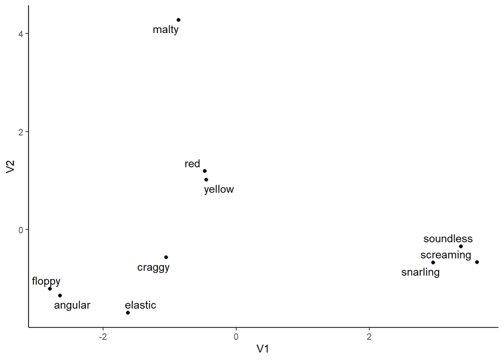

```r
coordinates%>%
  # we can take the rownames and put them in a column called "Word" in the dataframe we make
  as_data_frame(rownames="Word")%>%
  ggplot(aes(x=V1,y=V2,label=Word))+
  geom_point()+
  geom_text_repel()+
  theme_classic()
```

Now we can see that it has grouped together words that are “sensorily” similar.

This is also the technique that we will use in the final assignment!

In the assignment, you will be measuring the similarity of the cake words based on their *usage* (i.e. which pictures they are used to describe).

# Assessing the stress on the coordinates

Remember I said that `cmdscale()` makes the coordinates so they reflect the distances we calculated *as well as possible*.

How well it can actually do this depends on the dataset. For example, in large datasets, there may be just too much independent variation along different dimensions to be able to capture with two dimensions.

We can calculate the “stress” of a MDS representation of a distance matrix to get a sense for how accurately the distances are represented.

The formula for the stress looks like this:

$$Stress = \sqrt{\frac{\sum_{i<j}({d_{ij} - D_{ij}})^2 }{ \sum_{i<j}d_{ij}^2}}$$
- $d_{ij}$ are the original distances from our matrix (made with `dist()`) and $D_{ij}$ are the fitted distances between the coordinates generated by `cmdscale()` - the formula uses the sum of squares so that negative and positive differences are the same - it calculates the sum for all values where i<j (i.e. $\sum_{i<j}$) so that it compares each pair only once - it divides by $\sum_{i<j}d_{ij}^2$ to normalise the value to the range 0 to 1.0

This is just like how we figured out the distances to use for our original matrix, but now we are figuring out the distances between our *real distances* and the *distances between the coordinates* we made using `cmdscale()`.

R doesn’t come with a built-in stress function, but we can make our own function to calculate the stress on our coordinates, like this:

```r
stress <- function(d, D){
  sqrt(sum((d - D) ^ 2) / sum(d ^ 2))
}

# compare the real distances with the distances between the coordinates we made
stress(distances,dist(coordinates))
```

```
## [1] 0.1863761
```

## Interpreting (normalised) stress values

Normalised stress values are interpreted like this:

| Value | Interpretation |
| --- | --- |
| Stress >= 0.2 | Poor |
| 0.1 <= Stress < 0.2 | Fair |
| 0.05 <= Stress < 0.1 | Good |
| Stress < 0.05 | Excellent |

So our visualisation is a “fair” representation of the distances between the words based on their sense ratings!

However, what if we were to take a larger sample?

```r
norms%>%
  sample_n(30)%>%
  select(-PropertyBritish,-DominantModality)%>%
  column_to_rownames("Word")%>%
  dist()-> distances

coordinates <- cmdscale(distances)
stress(distances,dist(coordinates))
```

```
## [1] 0.1571162
```

Sometimes, a 3-dimensional solution or higher will work better. We can set the number of dimensions to use in `cmdscale()` with the argument `k`

```r
threeD_coordinates <- cmdscale(distances,k=3)
stress(distances,dist(threeD_coordinates))
```

```
## [1] 0.05784046
```

This is better, but a 3D solution is hard to plot

In this case, I would use a different visualisation technique.

# Cluster dendrograms

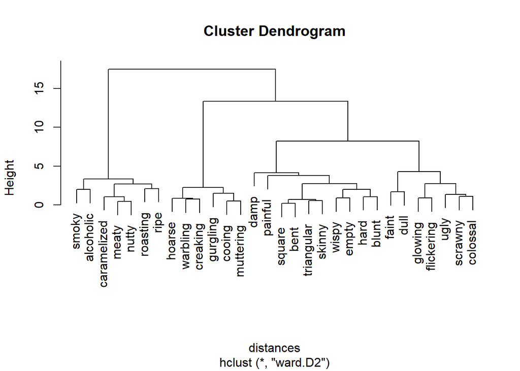

```r
tree <- hclust(distances,method="ward.D2")
plot(tree)
```

Cluster dendrograms aren’t perfect either though; they won’t always be able to accurately represent the distances, and different joining methods can produce different solutions. I recommend the method called “ward.D2”, but if you want to read about the other methods available (and the difference between them) you can do that [here](https://www.rdocumentation.org/packages/stats/versions/3.6.2/topics/hclust).

# Binary distances

If you don’t have numerical data, you can still create a distance matrix by converting your categorical data into a *binary* format first.

```r
japonic <- read_csv("data/japvocabmatrix.csv")
japonic%>%
  filter(X!="Old_Japanese",X!="Middle_Japanese",X!="Okinawa")%>%
  column_to_rownames("X")->japonic

japonic[1:10,1:7]%>%
  kable(col.names=c("ware","ore","temae","boku","jibun","ura","uchi"))%>%
  kable_styling()
```

|  | ware | ore | temae | boku | jibun | ura | uchi |
| --- | --- | --- | --- | --- | --- | --- | --- |
| Hokkaido_Coast | 0 | 1 | 0 | 0 | 0 | 0 | 0 |
| Hokkaido_Inland | 1 | 0 | 0 | 0 | 0 | 0 | 0 |
| Aomori_Tsugaru | 0 | 1 | 0 | 0 | 0 | 0 | 0 |
| Aomori_Nambu | 1 | 0 | 0 | 0 | 0 | 0 | 0 |
| Iwate | 0 | 1 | 0 | 0 | 0 | 0 | 0 |
| Miyagi | 1 | 0 | 0 | 0 | 0 | 0 | 0 |
| Akita | 1 | 1 | 0 | 1 | 0 | 0 | 0 |
| Yamagata | 0 | 1 | 0 | 0 | 0 | 0 | 0 |
| Fukushima | 1 | 1 | 0 | 0 | 0 | 0 | 0 |
| Ibaraki | 1 | 0 | 0 | 0 | 0 | 0 | 0 |

For example, this dataset contains a list of different locations in Japan (in the rows), and different words (in the columns). The first bunch of words are all words for the first person singular pronoun (I). If a language uses that word to mean ‘I’, it is coded as a 1, but if it doesn’t use that word, it is coded as a 0.

We can make a distance matrix from these 1s and 0s, to see how similar or far apart the locations are to eachother, based on how many words they share (the complete dataset contains hundreds of words, which would be impossible to plot as separate variables).

When we do this, we have to add an argument `method="binary"` to our dist function, to tell it the data has been binarised.

```r
distances <- dist(japonic,method="binary")
```

Then we can get coordinates for these distances using `cmdscale()`, and plot the distances between the languages

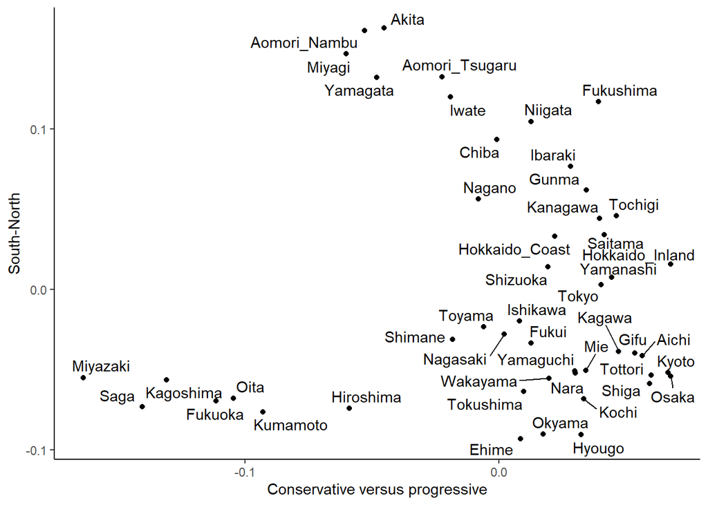

```r
coordinates <- cmdscale(distances)

coordinates%>%
  as_data_frame(rownames="Region")%>%
  ggplot(aes(x=V2,y=-V1,label=Region))+
  geom_point()+
  geom_text_repel()+
  theme_classic()+
  labs(x="Conservative versus progressive",y="South-North")
```

So, in this case, we can actually come up with some nice labels for our two dimensions that make sense.

Creating distance matrices is an easy way to examine dialectal or language data, when you want to compare languages based on (e.g.) lots of words, or lots of linguistic features (if you can binarise those features as yes/no features).

# Mapping data

The last thing I want to show you before you do the assignment is how to plot points on maps in R. You might want to do this in the assignment, if for instance you find some interesting geographical patterns. However, you will need to make a dataset with the latitude and longitude for the locations of the participants. You can do this easily using [google maps](https://www.google.com/maps). Just find the country on the map, and then if you right click on a spot in that country, you can copy the latitude and longitude. I give an example of how to do this below.

We can get maps from the packages `rnaturalearth` and `rnaturalearthdata`, and plot them using the `ggplot` function `geom_sf()`. `sf` is a file format for storing maps.

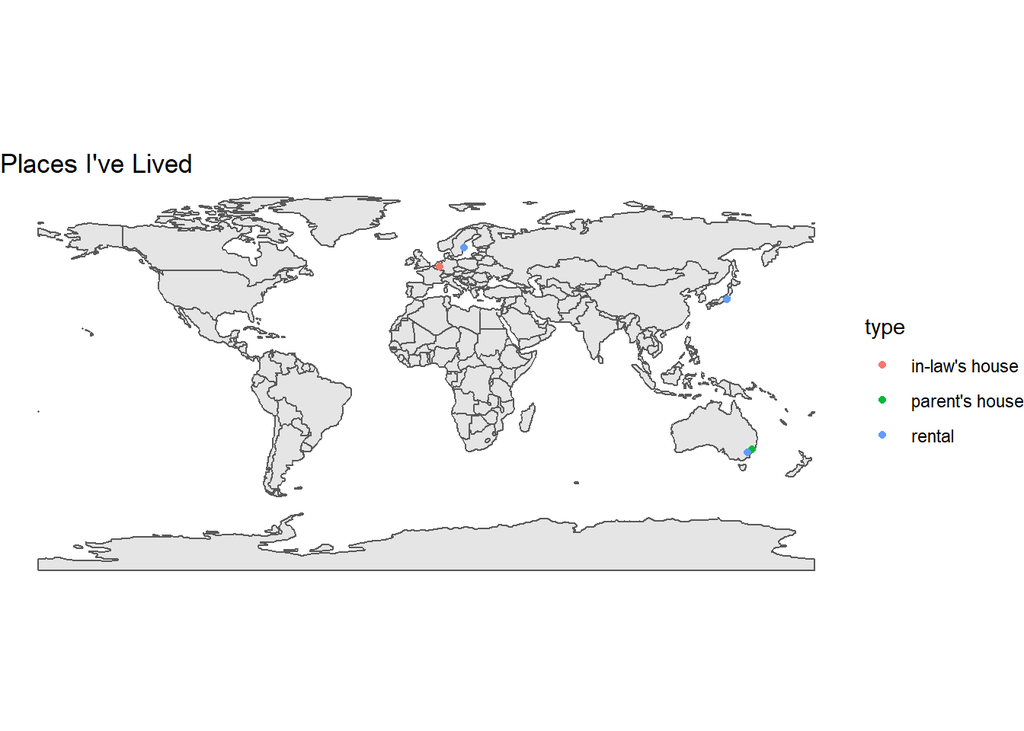

```r
# required packages
library(rnaturalearth)
library(rnaturalearthdata)
library(ggrepel)

# these packages may not function properly if you don't also have rgeos installed; if you get an error, run install.packages('rgeos') in your console and then try again

# the function ne_countries will give you country maps, if you don't specify which countries, it gives you the whole world.
# Use returnclass="sf" to make sure you get an sf format back, as this is what geom_sf() works with
world <- ne_countries(returnclass = "sf")

# you need to have latitude and longitude information for the things you want to plot -- I get this from google maps -- just right click on a place in google maps (on a computer), and the latitude and longitude will show up and you can copy them
type <- c("rental","parent's house","in-law's house","rental","rental")
latitude <- c(59.865,-33.879,50.874,35.664,-35.284)
longitude <- c(17.641,151.112,6.037,139.482,149.136)
places <- data.frame(type,latitude,longitude)

# start by plotting the map as a base layer
# this always has to come first -- it won't work if you start with the points and try to add the map after
world%>%
  ggplot()+
  geom_sf()+
  # then you can add points on top of it -- note that you need to specify the data, because this comes from a different dataset to the one at the top of the pipe
  geom_point(data = places,aes(x=longitude,y=latitude,colour=type))+
  theme_void()+    # this is a nice theme for maps; it gets rid of the axes
  labs(title="Places I've Lived")
```

You can use the ‘country’ argument in `ne_countries()` to get a map of a single country.

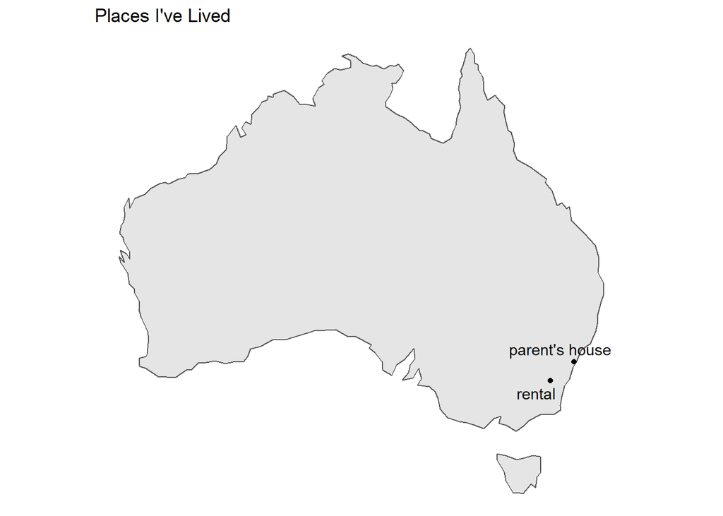

```r
Australia <- ne_countries(country="Australia",returnclass = "sf")

australian_places <- places%>%filter(latitude<0)

Australia%>%
  ggplot()+
  geom_sf()+
  # since the data isn't coming from the top of the pipe, you need to tell it the data and aesthetics
  geom_point(data = australian_places,aes(x=longitude,y=latitude))+
  # you could use labels instead of colour -- but again you need to tell it the aesthesics and data to use
  geom_text_repel(data = australian_places,aes(x=longitude,y=latitude,label=type))+
  labs(title="Places I've Lived")+
  theme_void()
```